# PADP_8120_Lab9: Regression

Tyler Scott

2015-08-15

# Lab Topics

- Linear regression

## Goals:

After this lab you will be able to: - explain what is a regression line and what is a residual is words, equations, and pictures - explain the relationship between a regression coefficient and a correlation coefficent in words, equations, and pictures

This lab uses materials by - Angela Dixon - Andrew Bray and Mine Cetinkaya-Rundel - Gael Varoquaux (https://github.com/cogmaster-stats) - Matthew Salganik

After this class you will have basic facility with simple linear models, including being able to - explain what is a regression line and what is a residual is words, equations, and pictures - explain the relationship between a regression coefficient and a correlation coefficent in words, equations, and pictures - compare and contrast extrapolation and interpolation - compare and contrast outliers, leverage, and influence

Note that in this class we are going to do this with single predictor models and next class we will do this with two predictor models.

## Example: Baseball!

The movie Moneyball focuses on the “quest for the secret of success in baseball”. It follows a low-budget team, the Oakland Athletics, who believed that underused statistics, such as a player’s ability to get on base, better predict the ability to score runs than typicalstatistics like home runs, RBIs (runs batted in), and batting average. Obtaining players who excelled in these underused statistics turned out to be much more affordable for the team.

In this lab we’ll be looking at data from all 30 Major League Baseball teams and examining the linear relationship between runs scored in a season and a number of other player statistics. Our aim will be to summarize these relationships both graphically and numerically in order to find which variable, if any, helps us best predict a team’s runs scored in a season.

## The data

Let’s load up the data for the 2011 season.

```r
load("input/mlb11.RData")
```

In addition to runs scored, there are seven traditionally used variables in the data set: at-bats, hits, home runs, batting average, strikeouts, stolen bases, and wins. There are also three newer variables: on-base percentage, slugging percentage, and on-base plus slugging. For the first portion of the analysis we’ll consider the seven traditional variables. At the end of the lab, you’ll work with the newer variables on your own.

1. What type of plot would you use to display the relationship between `runs` and one of the other numerical variables? Plot this relationship using the variable `at_bats` as the predictor. Does the relationship look linear? If you knew a team’s `at_bats`, would you be comfortable using a linear model to predict the number of runs?

We just need a scatter plot for this:

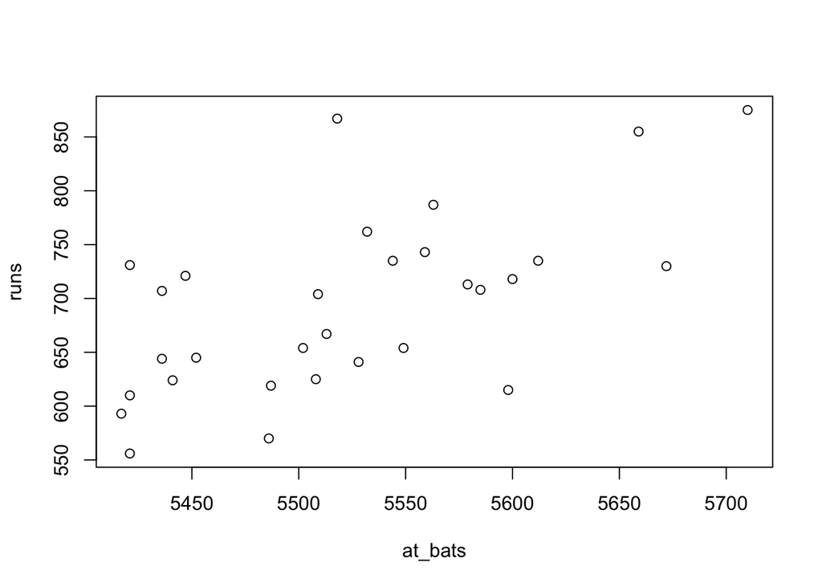

```r
plot(runs~at_bats,data=mlb11)
```

Looks like there is an upward linear trend.

If the relationship looks linear, we can quantify the strength of the relationship with the correlation coefficient.

```r
cor(mlb11$runs, mlb11$at_bats)
```

```
## [1] 0.610627
```

## Sum of squared residuals

Think back to the way that we described the distribution of a single variable. Recall that we discussed characteristics such as center, spread, and shape. It’s also useful to be able to describe the relationship of two numerical variables, such as `runs` and `at_bats` above.

2. Looking at your plot from the previous exercise, describe the relationship between these two variables. Make sure to discuss the form, direction, and strength of the relationship as well as any unusual observations.

Based upon the scatter plot above, it appears that at bats are positively related to runs scored. While there appears to be relatively high variance (for instance, look at the spread of teams with about 5525 at bats), in general there seems to be a consistent linear relationships.

Just as we used the mean and standard deviation to summarize a single variable, we can summarize the relationship between these two variables by finding the line that best follows their association. Use the following interactive function to select the line that you think does the best job of going through the cloud of points.

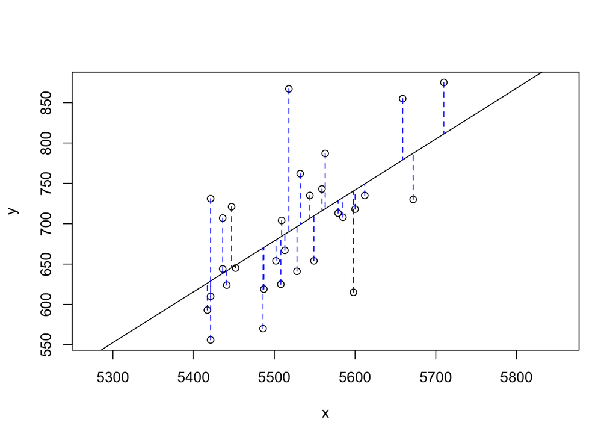

```
## Click two points to make a line.

## Call:
## lm(formula = y ~ x, data = pts)
##
## Coefficients:
## (Intercept)            x
##  -2789.2429       0.6305
##
## Sum of Squares:  123721.9
```

```r
plot_ss(x = mlb11$at_bats, y = mlb11$runs)
```

After running this command, you’ll be prompted to click two points on the plot to define a line. Once you’ve done that, the line you specified will be shown in black and the residuals in blue. Note that there are 30 residuals, one for each of the 30 observations. Recall that the residuals are the difference between the observed values and the values predicted by the line:

$e_i = y_i - \hat{y}_i$

The most common way to do linear regression is to select the line that minimizes the sum of squared residuals. To visualize the squared residuals, you can rerun the plot command and add the argument `showSquares = TRUE`.

```r
plot_ss(x = mlb11$at_bats, y = mlb11$runs, showSquares = TRUE)
```

Note that the output from the `plot_ss` function provides you with the slope and intercept of your line as well as the sum of squares.

3. Using `plot_ss`, choose a line that does a good job of minimizing the sum of squares. Run the function several times. What was the smallest sum of squares that you got?

## The linear model

It is rather cumbersome to try to get the correct least squares line, i.e. the line that minimizes the sum of squared residuals, through trial and error. Instead we can use the `lm` function in R to fit the linear model (a.k.a. regression line).

```r
model_atbats <- lm(runs ~ at_bats, data = mlb11)
```

The first argument in the function `lm` is a formula that takes the form `y ~ x`. Here it can be read that we want to make a linear model of `runs` as a function of `at_bats`. The second argument specifies that R should look in the `mlb11` data frame to find the `runs` and `at_bats` variables.

The output of `lm` is an object that contains all of the information we need about the linear model that was just fit. We can access this information using the summary function.

```r
summary(model_atbats)
```

```
##
## Call:
## lm(formula = runs ~ at_bats, data = mlb11)
##
## Residuals:
##     Min      1Q  Median      3Q     Max
## -125.58  -47.05  -16.59   54.40  176.87
##
## Coefficients:
##               Estimate Std. Error t value Pr(>|t|)
## (Intercept) -2789.2429   853.6957  -3.267 0.002871 **
## at_bats         0.6305     0.1545   4.080 0.000339 ***
## ---
## Signif. codes:  0 '***' 0.001 '**' 0.01 '*' 0.05 '.' 0.1 ' ' 1
##
## Residual standard error: 66.47 on 28 degrees of freedom
## Multiple R-squared:  0.3729, Adjusted R-squared:  0.3505
## F-statistic: 16.65 on 1 and 28 DF,  p-value: 0.0003388
```

Let’s consider this output piece by piece. First, the formula used to describe the model is shown at the top. After the formula you find the five-number summary of the residuals. The “Coefficients” table shown next is key; its first column displays the linear model’s y-intercept and the coefficient of `at_bats`. With this table, we can write down the least squares regression line for the linear model:

$\hat{y} = -2789.2429 + 0.6305 * atbats$

One last piece of information we will discuss from the summary output is the Multiple R-squared, or more simply, $R^2$. The $R^2$ value represents the proportion of variability in the response variable that is explained by the explanatory variable. For this model, 37.3% of the variability in runs is explained by at-bats. $R^2$ isn’t great, for reasons that we will talk about, but it works just fine for bivariate regression.

4. Fit a new model that uses `homeruns` to predict `runs`. Using the estimates from the R output, write the equation of the regression line. What does the slope tell us in the context of the relationship between success of a team and its home runs?

```r
model_homeruns = lm(runs ~ homeruns, data = mlb11)
summary(model_homeruns)
```

```
##
## Call:
## lm(formula = runs ~ homeruns, data = mlb11)
##
## Residuals:
##     Min      1Q  Median      3Q     Max
## -91.615 -33.410   3.231  24.292 104.631
##
## Coefficients:
##             Estimate Std. Error t value Pr(>|t|)
## (Intercept) 415.2389    41.6779   9.963 1.04e-10 ***
## homeruns      1.8345     0.2677   6.854 1.90e-07 ***
## ---
## Signif. codes:  0 '***' 0.001 '**' 0.01 '*' 0.05 '.' 0.1 ' ' 1
##
## Residual standard error: 51.29 on 28 degrees of freedom
## Multiple R-squared:  0.6266, Adjusted R-squared:  0.6132
## F-statistic: 46.98 on 1 and 28 DF,  p-value: 1.9e-07
```

The regression equation is: $y_i = 415.24 + 1.83 * Homeruns$. In other words, there is a positive relationship between homeruns hit and runs scored (causal in this case), as each home run predicts a 1.83 run increase in total runs scored. Thus, as we might expect, all else equal hitting more homeruns makes a team more successful.

## Prediction and prediction errors

Let’s create a scatterplot with the least squares line laid on top.

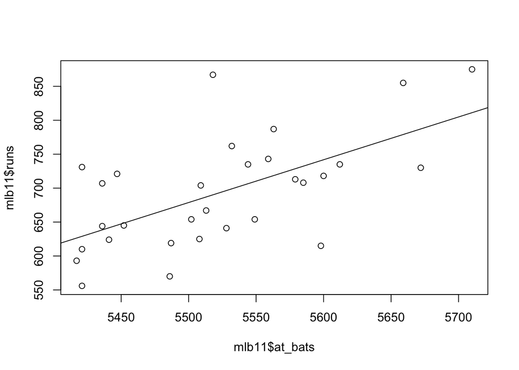

```r
plot(mlb11$runs ~ mlb11$at_bats)
abline(model_atbats)
```

5. If a team manager saw the least squares regression line and not the actual data, how many runs would he or she predict for a team with 5,578 at-bats? What is the residual for this prediction?
- We can do this by hand…

```r
model_atbats$coefficients[1] + model_atbats$coefficients[2] * 5578
```

[output not shown]

… or using R’s prediction tools:

```r
predict(model_atbats,newdata = data.frame('at_bats' = 5578))
```

[output not shown]

Due to the setup of the OLS model, the residual for a prediction is 0 (since each prediction falls right on then linear least-squares line).

6. Choose another traditional variable from `mlb11` that you think might be a good predictor of `runs`. Produce a scatterplot of the two variables and fit a linear model. At a glance, does there seem to be a linear relationship?

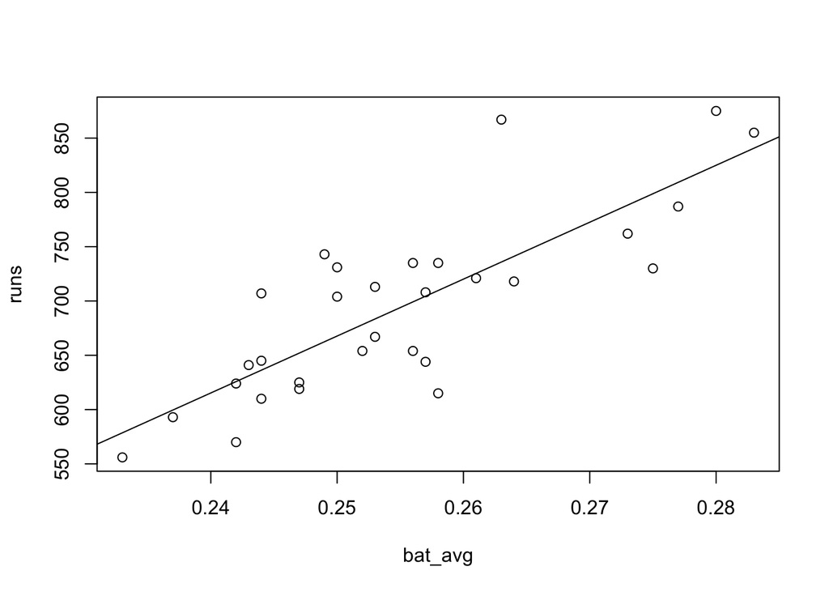

```r
plot(runs~bat_avg,data=mlb11)
batavgmod <- lm(runs ~ bat_avg,data=mlb11)
abline(batavgmod)
```

```r
summary(batavgmod)
```

```
##
## Call:
## lm(formula = runs ~ bat_avg, data = mlb11)
##
## Residuals:
##     Min      1Q  Median      3Q     Max
## -94.676 -26.303  -5.496  28.482 131.113
##
## Coefficients:
##             Estimate Std. Error t value Pr(>|t|)
## (Intercept)   -642.8      183.1  -3.511  0.00153 **
## bat_avg       5242.2      717.3   7.308 5.88e-08 ***
## ---
## Signif. codes:  0 '***' 0.001 '**' 0.01 '*' 0.05 '.' 0.1 ' ' 1
##
## Residual standard error: 49.23 on 28 degrees of freedom
## Multiple R-squared:  0.6561, Adjusted R-squared:  0.6438
## F-statistic: 53.41 on 1 and 28 DF,  p-value: 5.877e-08
```

There is a clear linear relationship between batting average and runs scored. Why is the coefficent so crazy? This is a good example of the need to thank carefully about the construct of your variable. Batting average is a ratio between 0 (no hits) and 1 (hit every time); a basic linear regression estimates the marginal impact of a one-unit increase in X. Thus, the coefficient for batting average shows that a 1.00 unit increase in batting average will increase runs scored by 5242.2. However, it is impossible to have a 1.00 unit increase in batting average; moreover, if you look at the scatterplot all batting averages fall within a small range between 0.200 and 0.300. Thus, while it will not change the statistical significance of the model, for presentation and interpretation it makes sense to scale the `bat_avg` variable. Multiplying the original varible by 100 will give us an interpretation of “each percentage point increase in batting average”, which is intuitive and straightforward. Note, however, that you could have accomplished this simply by dividing the original coefficient by 100.

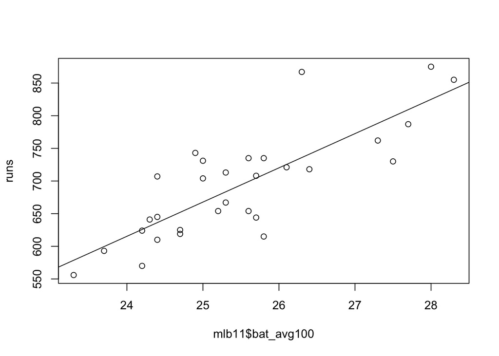

```r
mlb11$bat_avg100 = mlb11$bat_avg*100
plot(runs~mlb11$bat_avg100,data=mlb11)
batavgmod <- lm(runs ~ bat_avg100,data=mlb11)
abline(batavgmod)
```

```r
summary(batavgmod)
```

```
##
## Call:
## lm(formula = runs ~ bat_avg100, data = mlb11)
##
## Residuals:
##     Min      1Q  Median      3Q     Max
## -94.676 -26.303  -5.496  28.482 131.113
##
## Coefficients:
##             Estimate Std. Error t value Pr(>|t|)
## (Intercept) -642.819    183.080  -3.511  0.00153 **
## bat_avg100    52.422      7.173   7.308 5.88e-08 ***
## ---
## Signif. codes:  0 '***' 0.001 '**' 0.01 '*' 0.05 '.' 0.1 ' ' 1
##
## Residual standard error: 49.23 on 28 degrees of freedom
## Multiple R-squared:  0.6561, Adjusted R-squared:  0.6438
## F-statistic: 53.41 on 1 and 28 DF,  p-value: 5.877e-08
```

7. How does this relationship compare to the relationship between `runs` and `at_bats`? Does your variable seem to predict `runs` better than `at_bats`? How can you tell?

Batting average seems to be a better predictor of runs scored than homeruns. The batting average model has a higher F-statistic and a higher $R^2$ value. We can also use BIC/AIC to compare:

```r
AIC(batavgmod,model_homeruns)
```

```
##                df      AIC
## batavgmod       3 322.8518
## model_homeruns  3 325.3217
```

```r
BIC(batavgmod,model_homeruns)
```

```
##                df      BIC
## batavgmod       3 327.0554
## model_homeruns  3 329.5253
```

In both cases, the batting average model performs slightly better.

8. Now that you can summarize the linear relationship between two variables, investigate the relationships between `runs` and each of the other five traditional variables (i.e., variables without “new” in the name). Which variable best predicts `runs`? Support your conclusion using the graphical and numerical methods we’ve discussed. Note: find a way to do this that **does not** require you to type out 7 different models

```r
library(dplyr)
forms = paste0('runs~',names(mlb11 %>% select(-team,-runs,-contains('new'))))
model.results = lapply(forms,lm,data=mlb11)
library(plyr)
coef.df = ldply(model.results,coef) #use `ldply` in plyr package to make coefficient dataframe
names(coef.df) = c('intercept','slope'); coef.df$x.variable = names(mlb11 %>% select(-team,-runs,-contains('new')))
coef.df$AIC = lapply(model.results,AIC)
coef.df
```

```
##    intercept        slope   x.variable      AIC
## 1 -2789.2429    0.6305500      at_bats 340.8741
## 2  -375.5600    0.7588615         hits 324.0604
## 3   415.2389    1.8345416     homeruns 325.3217
## 4  -642.8189 5242.2290794      bat_avg 322.8518
## 5  1054.7342   -0.3141390   strikeouts 349.3053
## 6   677.3074    0.1490629 stolen_bases 354.7844
## 7   342.1214    4.3410280         wins 341.4378
## 8  -642.8189   52.4222908   bat_avg100 322.8518
```

You can probably come up with a more efficient way of doing this than I did… In any case, it looks like batting average outperforms all other traditional variables.

9. Now examine the three newer variables. These are the statistics used by the A’s as key indicators of success. In general, are they more or less effective at predicting runs than the old variables? Explain using appropriate graphical and numerical evidence. Of all ten variables we’ve analyzed, which seems to be the best predictor of `runs`? Using the limited (or not so limited) information you know about these baseball statistics, does your result make sense?

I’m going to repeat the code above, but now include the “new” variables:

```r
library(dplyr)
forms = paste0('runs~',names(mlb11 %>% select(-team,-runs)))
model.results = lapply(forms,lm,data=mlb11)
library(plyr)
coef.df = ldply(model.results,coef) #use `ldply` in plyr package to make coefficient dataframe
names(coef.df) = c('intercept','slope'); coef.df$x.variable = names(mlb11 %>% select(-team,-runs))
coef.df$AIC = lapply(model.results,AIC)
coef.df
```

```
##     intercept        slope   x.variable      AIC
## 1  -2789.2429    0.6305500      at_bats 340.8741
## 2   -375.5600    0.7588615         hits 324.0604
## 3    415.2389    1.8345416     homeruns 325.3217
## 4   -642.8189 5242.2290794      bat_avg 322.8518
## 5   1054.7342   -0.3141390   strikeouts 349.3053
## 6    677.3074    0.1490629 stolen_bases 354.7844
## 7    342.1214    4.3410280         wins 341.4378
## 8  -1118.4198 5654.3159609   new_onbase 298.1368
## 9   -375.8041 2681.3308863     new_slug 286.7189
## 10  -686.6143 1919.3635690      new_obs 272.9045
## 11  -642.8189   52.4222908   bat_avg100 322.8518
```

As you can see, the new statistics dramatically outperform traditional ones. The AIC values for onbase, slug, and obs are WAY lower. It appears that `obs` is the best predictor of runs. This makes sense, since `obs` captures all of the different ways a team can get on base (e.g., hits AND walks).

## Example 2: “Advances in Development Reverse Fertility Declines”

Next we will work with the recent, important paper in Nature by Mikko Myrskyla, Hans-Peter Kohler & Francesco C. Billari (2009). This paper examined the relationship between the Human Development Index (HDI) and the Total Fertility Rate (TFR) in 143 countries.

10. Download: http://www.nature.com/nature/journal/v460/n7256/extref/nature08230-s2.zip
11. Read the data into R (`read.csv`)

```r
nature = read.csv('input/nature08230-s2.csv')
```

12. Drop all but the HDI and TFR for 1975 and 2005 (use dplyr)

```r
library(dplyr)
nature <- nature %>% select(country,HDI.1975,HDI.2005,TFR.1975,TFR.2005)
```

13. Explore the dataset. Make some plots. Do some calculations. What do you see?

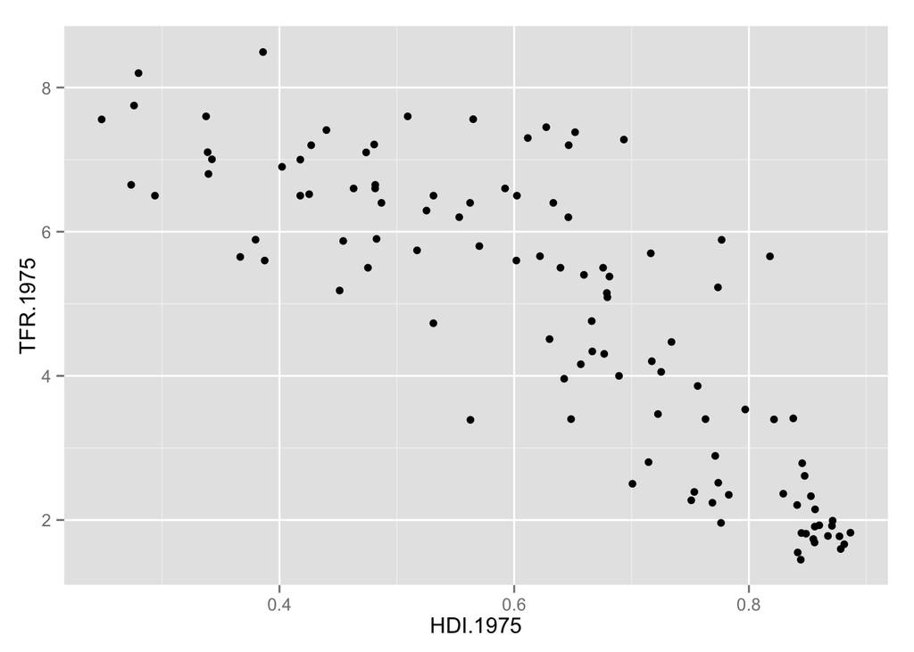

```r
library(ggplot2)
ggplot(data = nature,aes(x=HDI.1975,y=TFR.1975)) + geom_point()
```

14. Use “lm(y ~ x)” to regress TFR on HDI for 1975.

```r
model_hdi1975 <- lm(TFR.1975~HDI.1975,data=nature)
summary(model_hdi1975)
```

```
##
## Call:
## lm(formula = TFR.1975 ~ HDI.1975, data = nature)
##
## Residuals:
##     Min      1Q  Median      3Q     Max
## -2.1031 -0.8096 -0.1682  0.7112  3.0414
##
## Coefficients:
##             Estimate Std. Error t value Pr(>|t|)
## (Intercept)  10.9010     0.4096   26.61   <2e-16 ***
## HDI.1975     -9.6101     0.6217  -15.46   <2e-16 ***
## ---
## Signif. codes:  0 '***' 0.001 '**' 0.01 '*' 0.05 '.' 0.1 ' ' 1
##
## Residual standard error: 1.136 on 105 degrees of freedom
##   (36 observations deleted due to missingness)
## Multiple R-squared:  0.6947, Adjusted R-squared:  0.6918
## F-statistic:   239 on 1 and 105 DF,  p-value: < 2.2e-16
```

15. What is the observed relationship?
16. Use the coefficient in a sentence.

The scatter plot we drew shows a fairly clear negative linear relationship. Baed upon the the model results, a one-unit increase in a country’s human development index score is predicted to decrease the total fertility rate by 9.6.

17. Interpret the constant.

The constant is the estimated TFR when HDI is equal to zero (i.e., not a realistic possibility). In any case, then HDI = 0, the constant predicts that TFR will be 10.9.

## Notes about an lm() Object

- lm() doesn’t just spit out values, it stores anything you could ever need
- Use “str(model_hdi)” to look at the structure of linear model fit object. What’s inside?
- Can you print the coefficients?
- Add the regression line to your scatter plot.
- Can you print the true TFR and the predicted TFR side by side? (you will need to address the missing data issue)
- Instead of summary(lfit), try installing and using the “broom” package. Which one do you like better? (see ??broom for more information)

## Residuals

[Fortify and ggplot2](http://docs.ggplot2.org/0.9.3.1/fortify.lm.html)

The `fortify` function can help you do more with your linear model objects by generating a dataframe containing model residuals (and a whole bunch of other things that we will talk about in two weeks…). Also, note that the fortify function can be used on all sorts of other objects as well - it’s a powerfull tool intended to make all sorts of plotting tasks easier.

```r
resid1975.df = fortify(model_hdi1975)
```

- Make a new scatter plot of the residuals versus the fitted values.

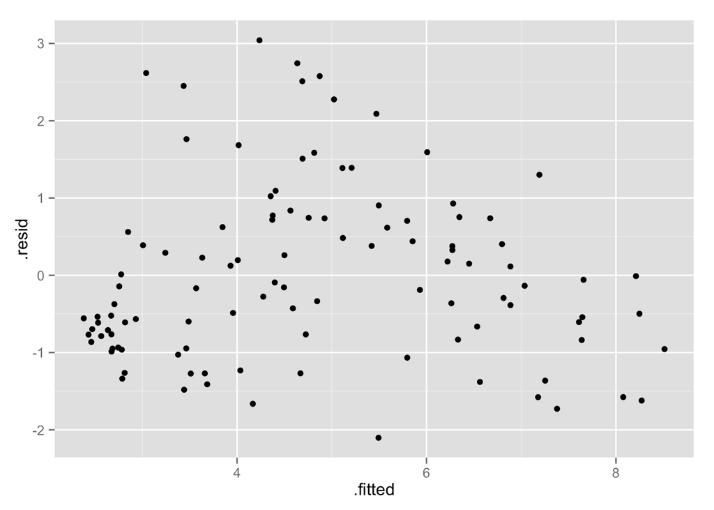

```r
ggplot(data=resid1975.df) + geom_point(aes(x=.fitted,y=.resid))
```

## Comparing 1975 to 2005

18. Return to the original HDI-TFR scatter plot and add the 2005 data to your scatter plot in red (change the axis titles and see if you can add a legend to make this new figure more “publishable”)

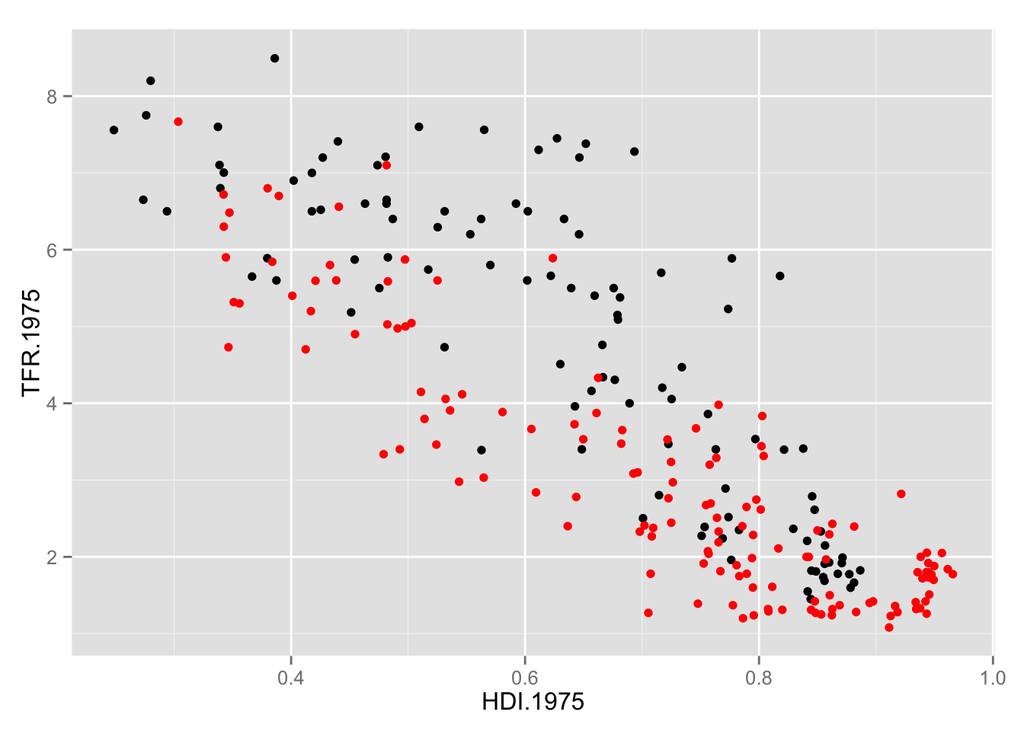

```r
ggplot(data = nature,aes(x=HDI.1975,y=TFR.1975)) + geom_point() +
  geom_point(data = nature,aes(x=HDI.2005,y=TFR.2005),col='red')
```

19. Perform the HDI on TFR regression for 2005 data.

```r
model_hdi2005 = lm(TFR.2005~HDI.2005,data=nature)
```

20. Add the new regression line to your plot.

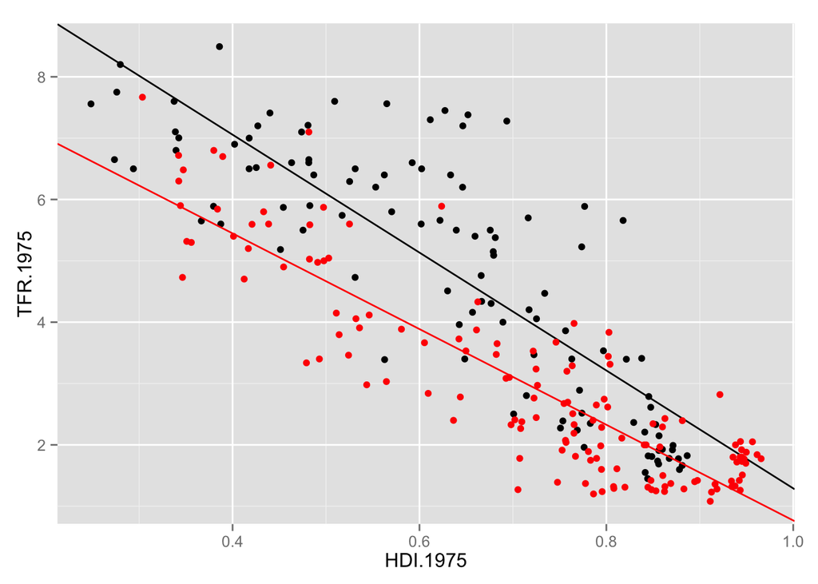

```r
ggplot(data = nature,aes(x=HDI.1975,y=TFR.1975)) + geom_point() +
  geom_abline(aes(slope=model_hdi1975$coefficients[2],intercept = model_hdi1975$coefficients[1]))+
geom_point(data = nature,aes(x=HDI.2005,y=TFR.2005),col='red') +
geom_abline(
  aes(intercept = model_hdi2005$coefficients[1],slope=model_hdi2005$coefficients[2]),col='red')
```

21. Did the relationship change from 1975 to 2005?

```r
library(texreg)
screenreg(list(model_hdi1975,model_hdi2005))
```

```
##
## ===================================
##              Model 1     Model 2
## -----------------------------------
## (Intercept)   10.90 ***    8.57 ***
##               (0.41)      (0.26)
## HDI.1975      -9.61 ***
##               (0.62)
## HDI.2005                  -7.80 ***
##                           (0.35)
## -----------------------------------
## R^2            0.69        0.78
## Adj. R^2       0.69        0.78
## Num. obs.    107         140
## RMSE           1.14        0.76
## ===================================
## *** p < 0.001, ** p < 0.01, * p < 0.05
```

The relationship changed somewhat, as the slope decreased in magnitude (i.e., moved closer to zero). Overall, however, the basic relationship seems to be about the same; what we observe in the plot is that HDI has increased on the whole, and TFR has decreased on the whole, so the intercept is really what shifted (althought you might also notice the cluster of high HDI countries at the far right, which perhaps indicates that a different model would be preferable for the 2005 data).

22. Make some aesthetic improvements to the graph

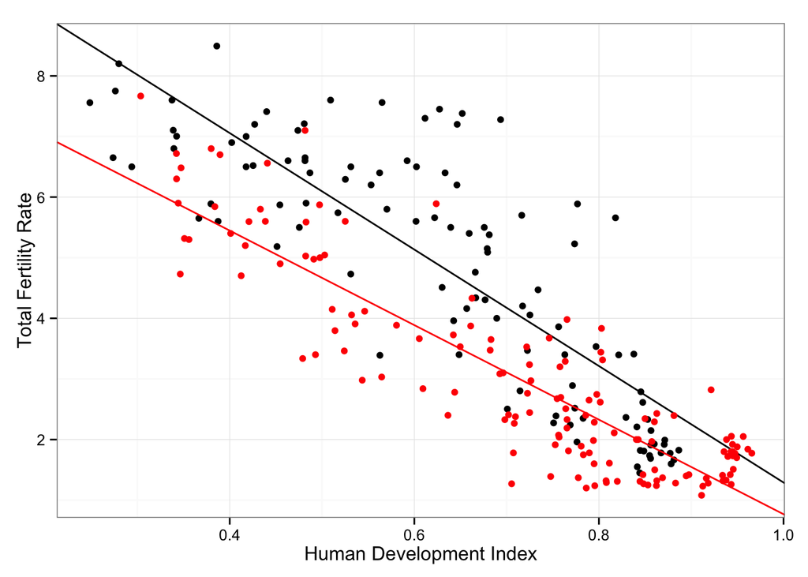

```r
ggplot(data = nature,aes(x=HDI.1975,y=TFR.1975)) + geom_point() +
  geom_abline(aes(slope=model_hdi1975$coefficients[2],intercept = model_hdi1975$coefficients[1]))+
geom_point(data = nature,aes(x=HDI.2005,y=TFR.2005),col='red') +
geom_abline(
  aes(intercept = model_hdi2005$coefficients[1],slope=model_hdi2005$coefficients[2]),col='red') +
  theme_bw() +
  ylab('Total Fertility Rate') + xlab('Human Development Index')
```

23. Make a new scatter plot of the residuals versus the fitted values for the 2005 data.

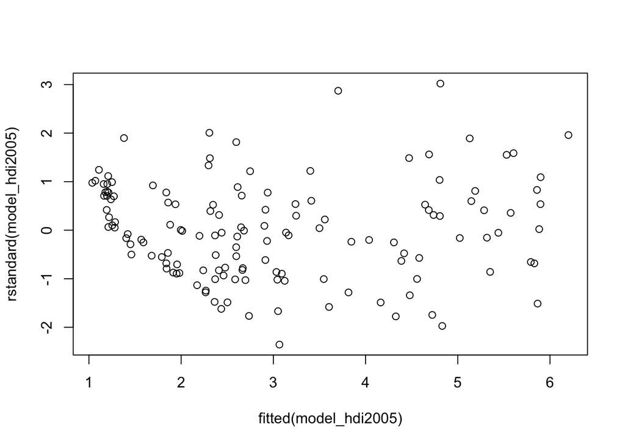

```r
plot(rstandard(model_hdi2005)~fitted(model_hdi2005))
```